# NYC Taxi EDA

## Explicação do problema

Queremos examinar quais fatores contribuem para períodos de viagem mais curtos ou mais longos nas viagens de táxi em Nova York.

## Insights

### Queda nas corridas em um determinado período

Foi identificado uma queda nas corridas entre os meses de Janeiro e Fevereiro, uma possível causa seja o inverno em Nova York.

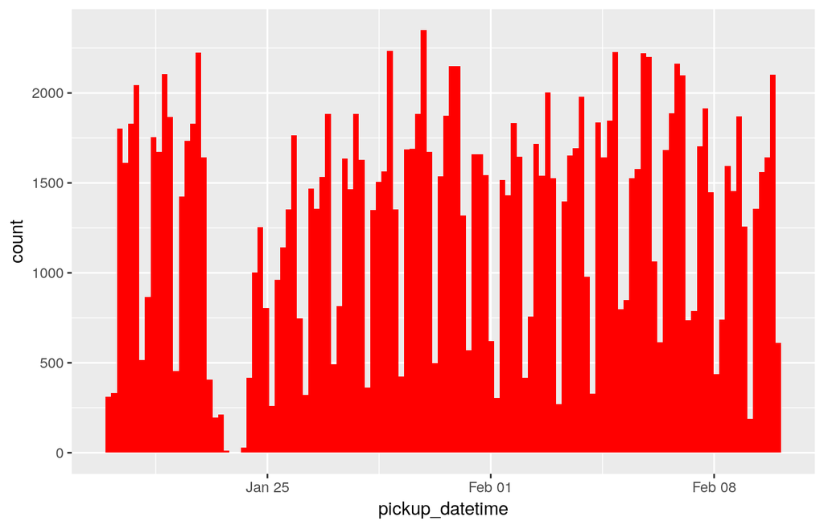

Obtendo os dados dos boletins meteorológicos do período em questão, podemos comparar as estatísticas de queda de neve com os números de nossas viagens por dia.

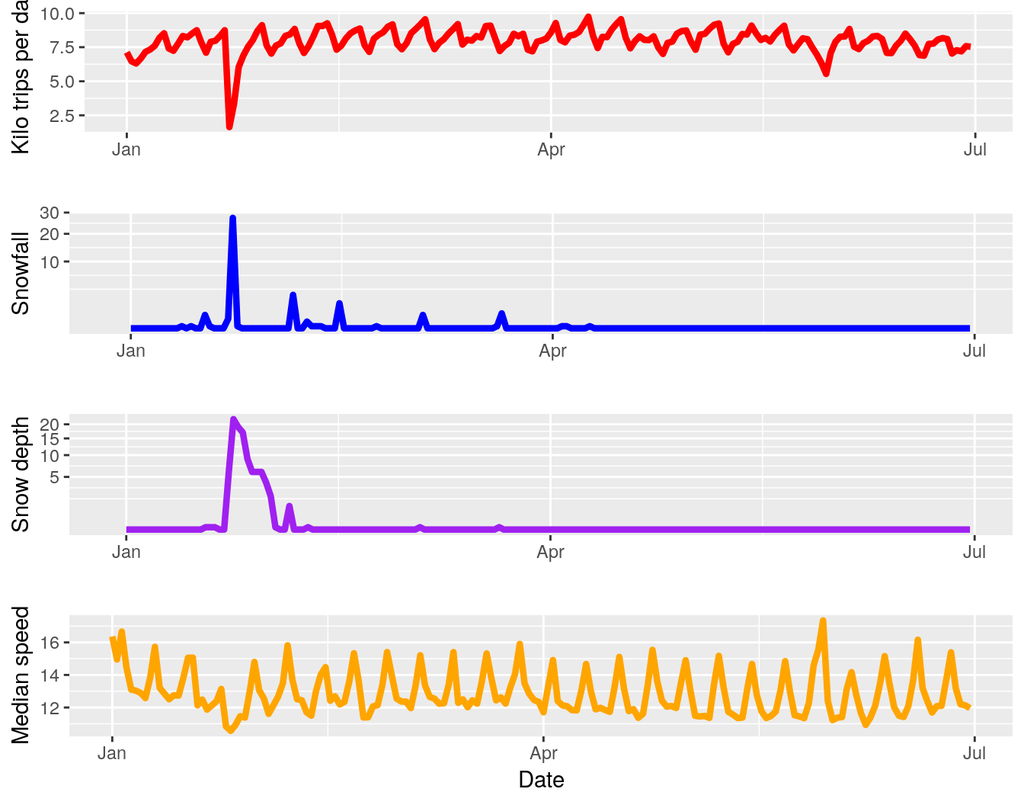

### Data e hora da corrida VS duração

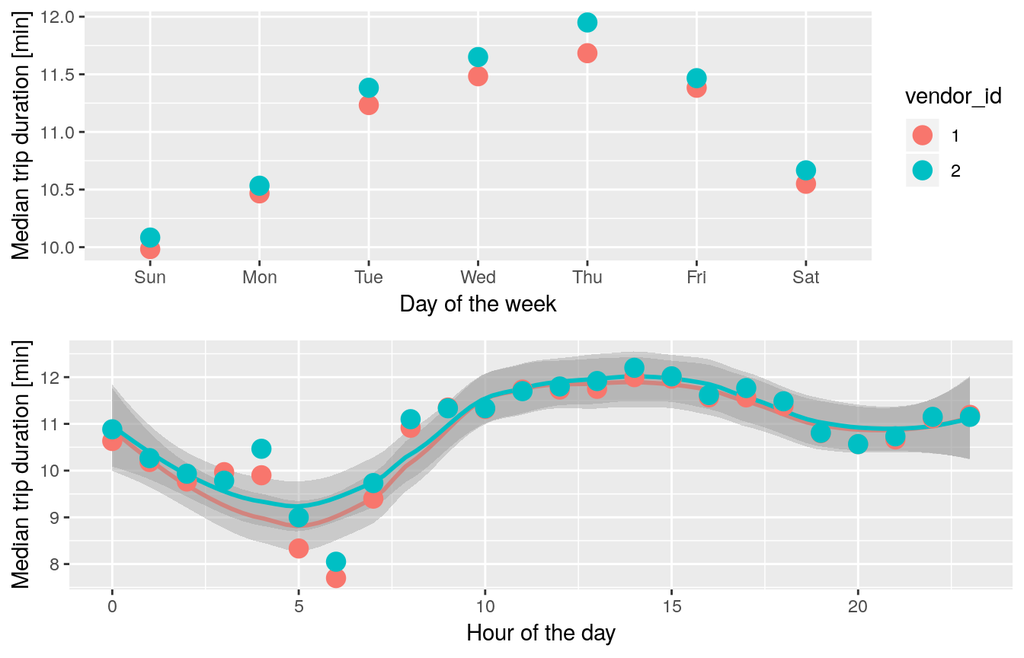

Como podemos ver no gráfico acima, entre terça e sexta-feira são os dias com mais duração de tempo, e esse padrão é similar para os dois vendor_id. No gráfico seguinte, ao longo do dia encontramos um pico no início da tarde.

### Visualizando características individuais

[figure not shown]

Ponto interessante aqui foi a análise dos dados de uma outra pespectiva, no caso em um mapa. Analisando a imagem percebemos que quase todas as viagens foram de fato feitas apenas em Manhattan. Outro ponto notável é o aeroporto JFK para o sul-leste da cidade.

## Comandos aprendidos

Similar ao ‘read.table’ só que mais rápido

```r
fread('./data/train.csv') %>%
  summary()
```

```
##       id              vendor_id     pickup_datetime    dropoff_datetime
##  Length:1458644     Min.   :1.000   Length:1458644     Length:1458644
##  Class :character   1st Qu.:1.000   Class :character   Class :character
##  Mode  :character   Median :2.000   Mode  :character   Mode  :character
##                     Mean   :1.535
##                     3rd Qu.:2.000
##                     Max.   :2.000
##  passenger_count pickup_longitude  pickup_latitude dropoff_longitude
##  Min.   :0.000   Min.   :-121.93   Min.   :34.36   Min.   :-121.93
##  1st Qu.:1.000   1st Qu.: -73.99   1st Qu.:40.74   1st Qu.: -73.99
##  Median :1.000   Median : -73.98   Median :40.75   Median : -73.98
##  Mean   :1.665   Mean   : -73.97   Mean   :40.75   Mean   : -73.97
##  3rd Qu.:2.000   3rd Qu.: -73.97   3rd Qu.:40.77   3rd Qu.: -73.96
##  Max.   :9.000   Max.   : -61.34   Max.   :51.88   Max.   : -61.34
##  dropoff_latitude store_and_fwd_flag trip_duration
##  Min.   :32.18    Length:1458644     Min.   :      1
##  1st Qu.:40.74    Class :character   1st Qu.:    397
##  Median :40.75    Mode  :character   Median :    662
##  Mean   :40.75                       Mean   :    959
##  3rd Qu.:40.77                       3rd Qu.:   1075
##  Max.   :43.92                       Max.   :3526282
```

Exibe um mapa interativo

```r
leaflet() %>%
  addProviderTiles("Esri.NatGeoWorldMap")
```

[interactive chart not shown]